# 합계출산율과 자산 및 부채

## 3. 결론

- 5년전의 경우 일괄적으로 음의 방향으로 관계성을 나타나고 있다.
- 2년전의 경우 자산과 부채가 양의 방향으로 관계성을 나타내고 있다.

### 3.1 5년전

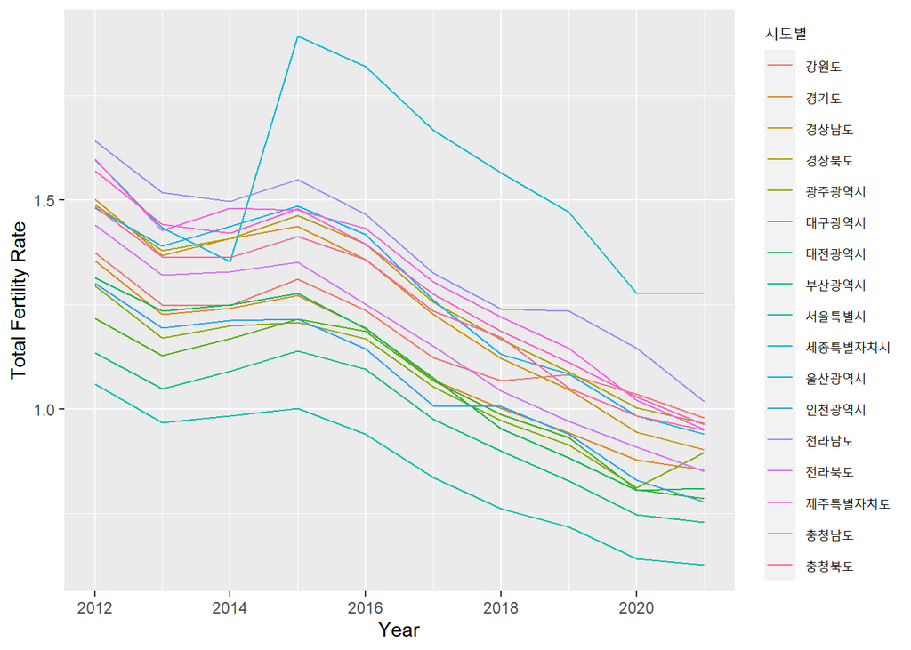

```r
file_path <- "./data/source/시도_합계출산율__모의_연령별_출산율_20230426100712.csv"
birth.rate.origin <- read.csv(file_path, na.strings = "-", header = T, encoding = "EUC-KR", fileEncoding = "EUC-KR")
View(birth.rate.origin)

ggplot(birth.rate.origin, aes(x=시점, y=합계출산율, col=시도별)) +
  geom_line() +
  xlab("Year") +
  ylab("Total Fertility Rate")
```

* 데이터 중 가장 최근 연도인 2021년의 5년전은 2016년이다. * 2016년부터 합계출산율은 꾸준히 감소폭을 그리고 있음으로  
꾸준히 증가하는 자산에 일괄적으로 영향을 받은 것으로 추측된다.

### 3.2 2년전

- 자산과 부채가 모두 2년전에 상승하는 것과  
  경상소득이 2년전과 무관한 것으로 보아  
  부채로 인한 자산의 증가라고 추측할 수 있다.
- 따라서 출산을 위한 자금을 마련하는 기간을 2년전으로 추측해 볼 수 있다.
- 출산을 위한 자금 마련으로는 결혼자금, 이사비용 등으로 추측되며  
  이를 통해 부채가 미혼율에 영향을 끼치는 지 알아 볼 필요성을 느꼈다.